# CCS Knowledge Map Results: Air Quality

Corey Jackson

2024-03-11

# Air Quality Survey

1 **Do you feel you are experiencing air quality problems in your neighborhood? If so, what are the specific air quality problems, and how are they impacting you, your family, or your neighbors?** (Open-ended)

# Indices

These indices provide a composite score reflecting various factors, including economic, health, and environmental indicators, which can significantly affect community perceptions.

## [Social Vulnerability Index](https://www.atsdr.cdc.gov/placeandhealth/svi/index.html)

```r
#datatable(svi_response)
```

## [Environmental Justice Index Indicators](https://www.atsdr.cdc.gov/placeandhealth/eji/indicators.html)

```r
#datatable(eji_response)
```

## [Environmental Justice Index Indicators](https://www.epa.gov/ejscreen/ej-and-supplemental-indexes-ejscreen)

```r
#datatable(ejscreen_response)
```

# Analysis

Comparative Analysis - Use comparative statistics (t-tests, ANOVA) to determine if there are statistically significant differences in responses between demographic groups, geographic locations, or SVI/EJI categories. For example, comparing the importance of tree benefits between communities with high vs. low vulnerability scores.

Regression Analysis - Conduct regression analyses (linear regression, logistic regression) to examine the relationship between demographic or SVI/EJI indicators and specific perceptions or attitudes. This can help identify factors that most strongly predict positive or negative perceptions. For example, if people from low vulnerability areas are more/less likely to report issues.

Correlation Analysis - Explore correlations between SVI/EJI scores and survey responses to see if higher vulnerability or environmental injustice scores are associated with specific perceptions or concerns about trees and green spaces.

# Air Quality Analysis

## Response Summary

**Have you or anyone you know experienced the following health issues related to poor air quality?**

```r
datatable(pol_impact)
```

|  | response | count | freq |
| --- | --- | --- | --- |
| 1 | Asthma | 89 | 30 |
| 2 | Lung Cancer | 29 | 10 |
| 3 | Respiratory Issues | 191 | 65 |
| 4 |  | 2 | 1 |

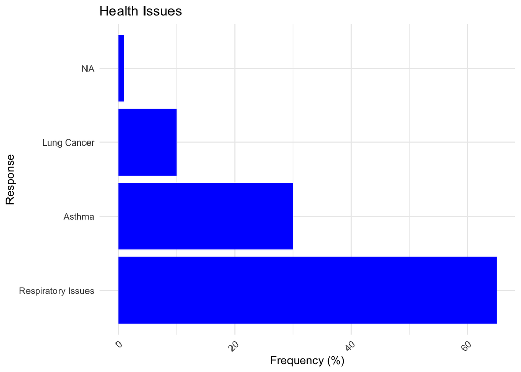

```r
pol_impact_viz
```

### Community Pollution Sources

**What do you think are the sources of air pollution in your community**

```r
datatable(pol_sources)
```

|  | response | count | freq |
| --- | --- | --- | --- |
| 1 | Mobile sources (e.g., cars, buses, trains) | 124 | 42 |
| 2 | Natural sources (e.g., wind-blown dust) | 75 | 25 |
| 3 | Pollution producing sites from agricultural areas, cities and wood-burning appliances | 40 | 14 |
| 4 | Stationary sources (e.g., power plants, industrial facilities and factories, oil refineries) | 104 | 35 |

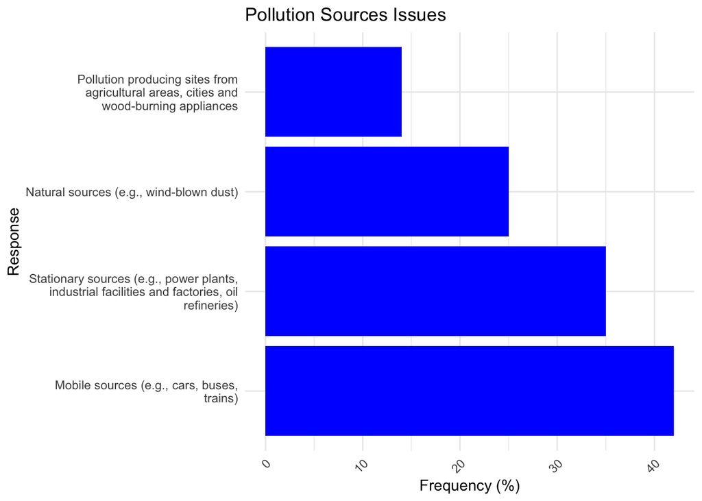

```r
pol_sources_viz
```

### Community Air Quality Changes

**Have you noticed any changes in air quality in your community over the past 5 years?**

```r
datatable(pol_changes)
```

|  | response | count | freq |
| --- | --- | --- | --- |
| 1 | I do not feel any changes in the air quality | 78 | 26 |
| 2 | No, air quality has decreased | 104 | 35 |
| 3 | Yes, air quality has improved | 113 | 38 |

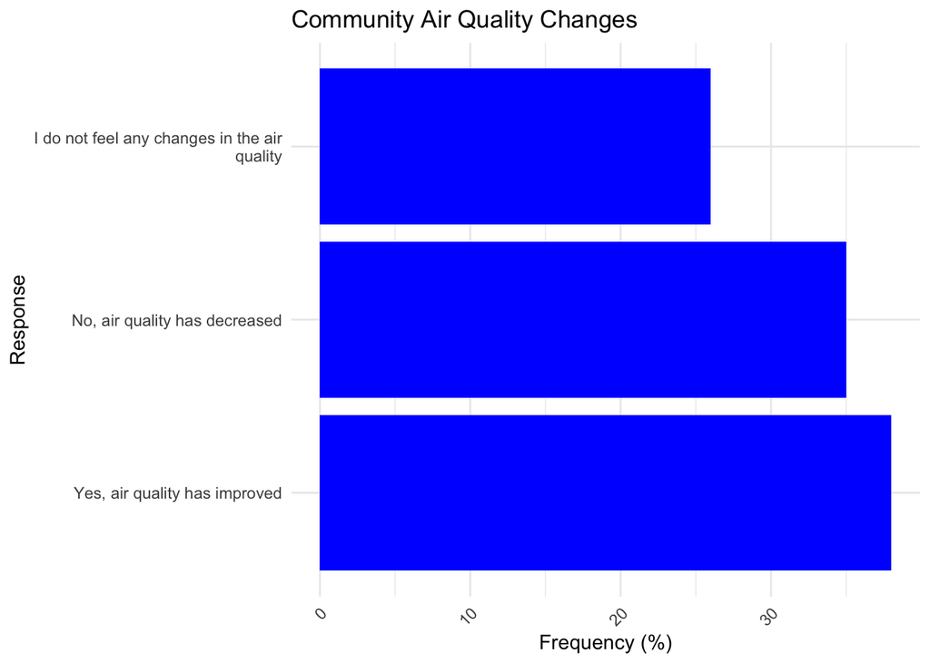

```r
pol_changes_viz
```

### PM and Ground-level Ozone

**Did you know Particulate matter (PM) and ground-level Ozone are common air contaminants harmful to human health?**

```r
datatable(pol_contam)
```

|  | response | count | freq |
| --- | --- | --- | --- |
| 1 | No | 114 | 39 |
| 2 | Yes | 182 | 61 |

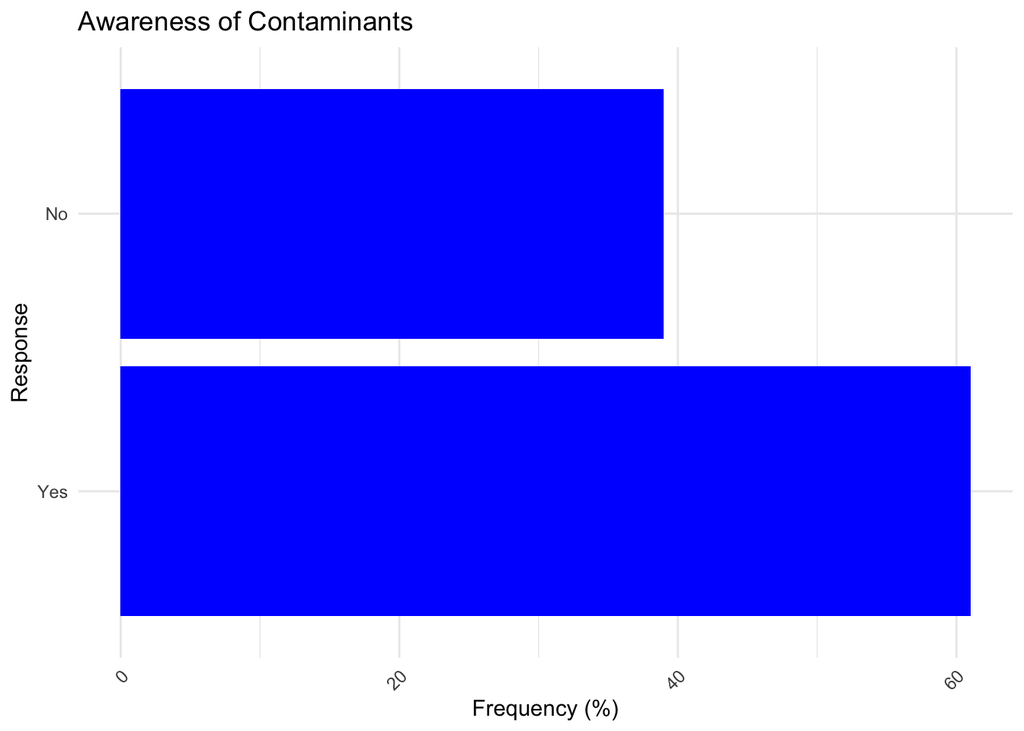

```r
pol_contam_viz
```

### Air Quality Monitors

**If you are providing suggestions for the city regarding where to install air quality monitoring sensors across Madison. Where would you like to see these sensors located?**

```r
datatable(pol_sensor)
```

|  | response | count | freq |
| --- | --- | --- | --- |
| 1 | Residential areas | 157 | 53 |
| 2 | Schools | 122 | 41 |
| 3 | Shopping area | 75 | 25 |

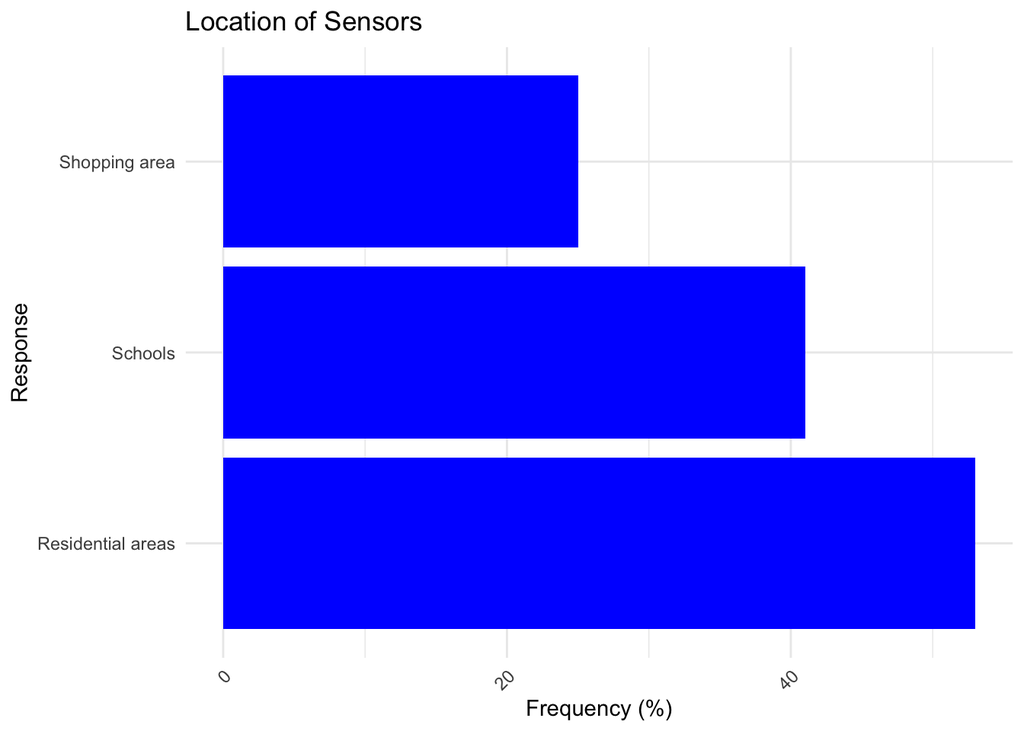

```r
pol_sensor_viz
```

### Being Informed about Air Quality

**If air quality becomes an issue and alerts need to be sent, how would you like to receive information about the air quality in your neighborhood?**

```r
datatable(pol_alerts)
```

|  | response | count | freq |
| --- | --- | --- | --- |
| 1 | Neighborhood associations | 5 | 2 |
| 2 | Newsletter from the city/county to your email | 133 | 45 |
| 3 | Newsletters from the city/county to your email | 28 | 9 |
| 4 | Social Media | 140 | 47 |
| 5 | Text Messages | 150 | 51 |
| 6 | neighborhood associations | 71 | 24 |

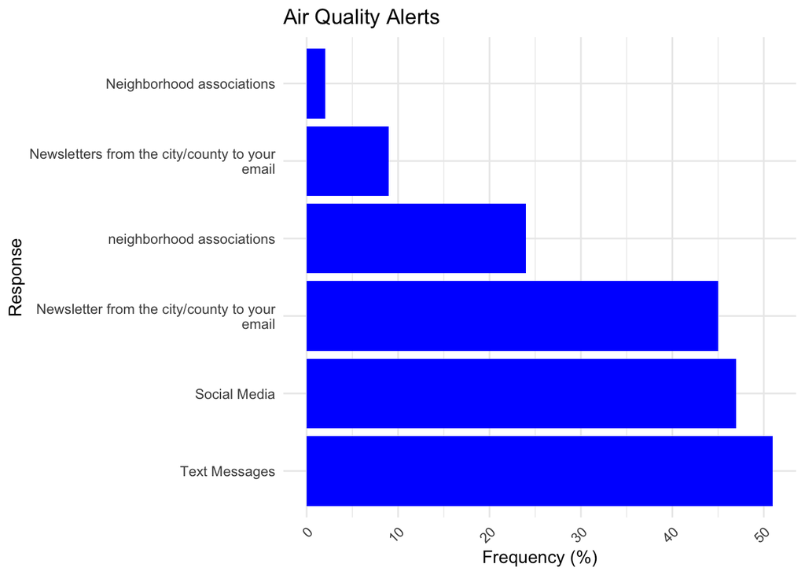

```r
pol_alerts_viz
```

### Deploying AQ Sensors Follow-up

**If there will be opportunities for you to participate in deciding where to deploy the air quality monitoring sensors. How would you like to be part of it? What roles would you like to take?**

```r
datatable(pol_interest)
```

|  | response | count | freq |
| --- | --- | --- | --- |
| 1 | Attending a community outreach event | 54 | 18 |
| 2 | Attending the community outreach event | 126 | 43 |
| 3 | Connect with local working group to be the messenger to deliver this information to your neighborhood | 86 | 29 |
| 4 | Connecting with local working group to be the messenger to deliver this information to your neighborhood | 24 | 8 |

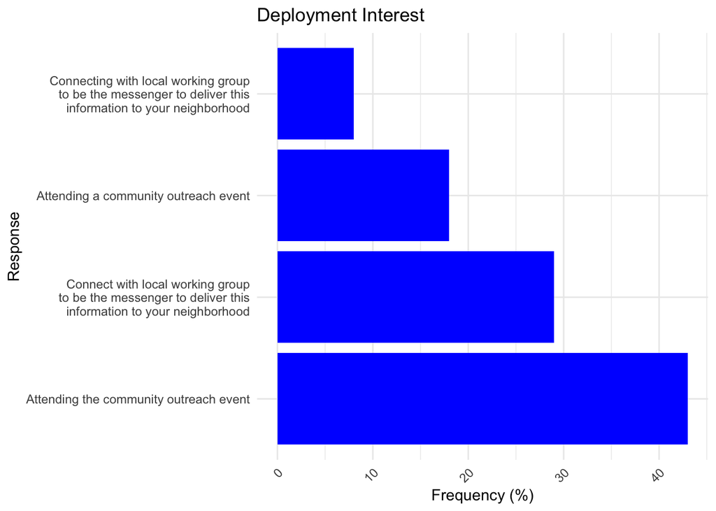

```r
pol_interest_viz
```

# Categorizing Vulnerability

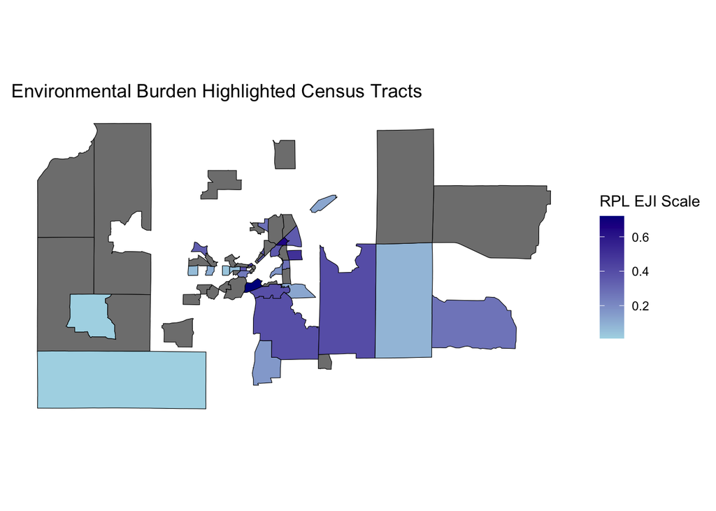

```r
county_data
```

In our analysis, we categorized vulnerability based on the Environmental Burden Module (RPL_EBM) percentile ranks derived from the 2022 Environmental Justice Index. To do this, we first determined the 25th (Q1) and 75th (Q3) percentile values of the RPL_EBM distribution. These percentile values served as thresholds to categorize regions based on their environmental burden. Specifically, regions with an RPL_EBM value greater than the 75th percentile (Q3) were categorized as “Most Vulnerable”, indicating that they are in the top quartile of environmental burden and, therefore, face higher vulnerability to environmental injustices. Conversely, regions not exceeding this threshold were categorized as “Least Vulnerable”. This method of categorization allows us to identify areas with the most significant environmental challenges and prioritize them for interventions and resource allocation.

```r
datatable(summary_eji)
```

|  | vulnerable | E_TOTPOP_mean | SPL_EJI_mean | RPL_EJI_mean | RPL_EBM_mean | EPL_OZONE_mean | EPL_PM_mean | EPL_DSLPM_mean | EPL_TOTCR_mean | SPL_EBM_THEME1_mean | RPL_EBM_DOM1_mean |
| --- | --- | --- | --- | --- | --- | --- | --- | --- | --- | --- | --- |
| 1 | Least | 5116.857 | 0.737 | 0.226 | 0.36 | 0.178 | 0.537 | 0.414 | 0.153 | 1.281 | 0.264 |
| 2 | Most | 4301 | 1.13 | 0.423 | 0.805 | 0.352 | 0.57 | 0.583 | 0.217 | 1.718 | 0.435 |

2. **Have you or anyone you know experienced the following health issues related to poor air quality?** (Multi-choice)
- Respiratory Issues
- Asthma
- Lung Cancer

```r
datatable(vulnerable_q2)
```

|  | vulnerable | question | n | total | freq |
| --- | --- | --- | --- | --- | --- |
| 1 | Least | Asthma | 10 | 42 | 24 |
| 2 | Least | Lung Cancer | 6 | 42 | 14 |
| 3 | Least | Respiratory Issues | 26 | 42 | 62 |
| 4 | Most | Asthma | 5 | 12 | 42 |
| 5 | Most | Respiratory Issues | 8 | 12 | 67 |

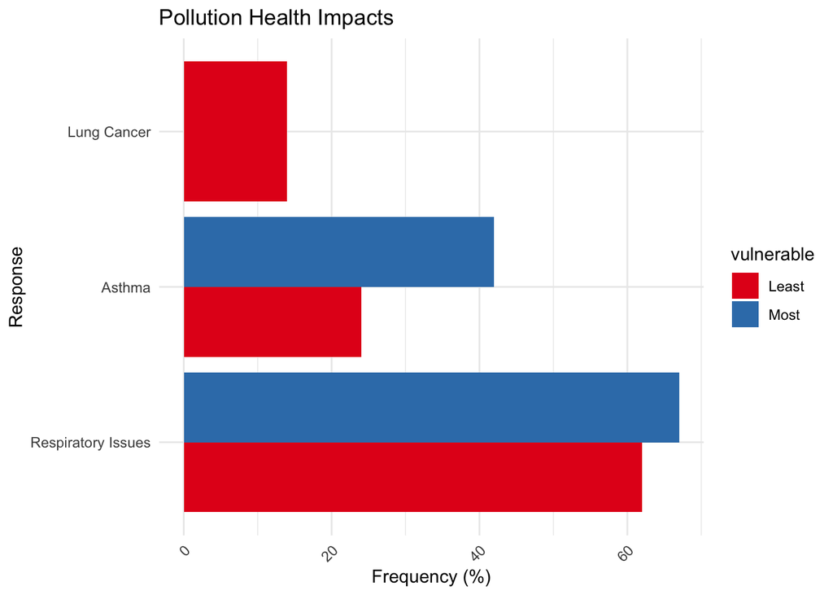

```r
vulnerable_q2_viz
```

```r
datatable(vulnerable_q2_chi)
```

|  | question | statistic | pvalue | degreeof |
| --- | --- | --- | --- | --- |
| 1 | Asthma | 1.667 | 0.197 | 1 |
| 2 | Lung Cancer | 6 | 0.014 | 1 |
| 3 | Respiratory Issues | 9.529 | 0.002 | 1 |

3. **What do you think are the sources of air pollution in your community?** (Multi-choice)
- Stationary sources (e.g., power plants, industrial facilities and factories, oil refineries)
- Mobile sources (e.g., cars, buses, trains)
- Natural sources (e.g., wind-blown dust)
- Pollution producing sites from agricultural areas, cities and wood-burning appliances

```r
datatable(vulnerable_q3)
```

|  | vulnerable | question | n | total | freq |
| --- | --- | --- | --- | --- | --- |
| 1 | Least | Mobile sources (e.g., cars, buses, trains) | 15 | 42 | 36 |
| 2 | Least | Natural sources (e.g., wind-blown dust) | 11 | 42 | 26 |
| 3 | Least | Pollution producing sites from agricultural areas, cities and wood-burning appliances | 9 | 42 | 21 |
| 4 | Least | Stationary sources (e.g., power plants, industrial facilities and factories, oil refineries) | 15 | 42 | 36 |
| 5 | Most | Mobile sources (e.g., cars, buses, trains) | 5 | 12 | 42 |
| 6 | Most | Natural sources (e.g., wind-blown dust) | 4 | 12 | 33 |
| 7 | Most | Pollution producing sites from agricultural areas, cities and wood-burning appliances | 3 | 12 | 25 |
| 8 | Most | Stationary sources (e.g., power plants, industrial facilities and factories, oil refineries) | 4 | 12 | 33 |

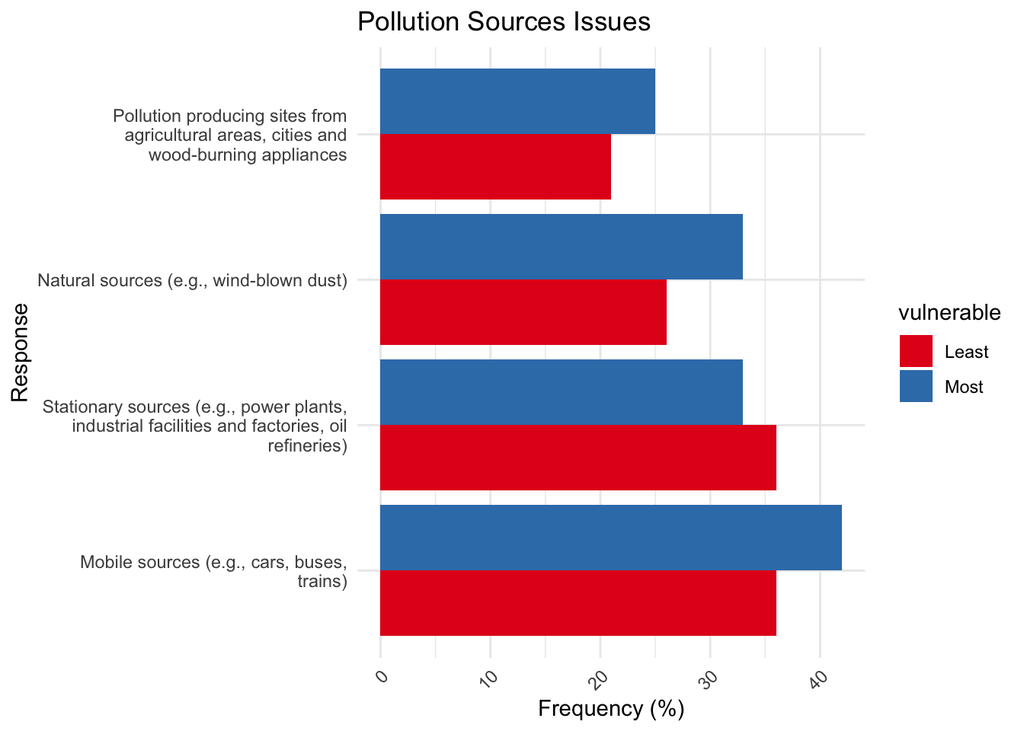

```r
vulnerable_q3_viz
```

```r
datatable(vulnerable_q3_chi)
```

|  | question | statistic | pvalue | degreeof |
| --- | --- | --- | --- | --- |
| 1 | Mobile sources (e.g., cars, buses, trains) | 5 | 0.025 | 1 |
| 2 | Natural sources (e.g., wind-blown dust) | 3.267 | 0.071 | 1 |
| 3 | Pollution producing sites from agricultural areas, cities and wood-burning appliances | 3 | 0.083 | 1 |
| 4 | Stationary sources (e.g., power plants, industrial facilities and factories, oil refineries) | 6.368 | 0.012 | 1 |

4. **Have you noticed any changes in air quality in your community over the past 5 years?** (Select Box)
- Yes, air quality has improved
- No, air quality has decreased
- I do not feel any changes in the air quality

```r
datatable(vulnerable_q4)
```

|  | vulnerable | question | n | total | freq |
| --- | --- | --- | --- | --- | --- |
| 1 | Least | I do not feel any changes in the air quality | 5 | 42 | 12 |
| 2 | Least | No, air quality has decreased | 13 | 42 | 31 |
| 3 | Least | Yes, air quality has improved | 24 | 42 | 56.99999999999999 |
| 4 | Most | I do not feel any changes in the air quality | 1 | 12 | 8 |
| 5 | Most | No, air quality has decreased | 6 | 12 | 50 |
| 6 | Most | Yes, air quality has improved | 5 | 12 | 42 |

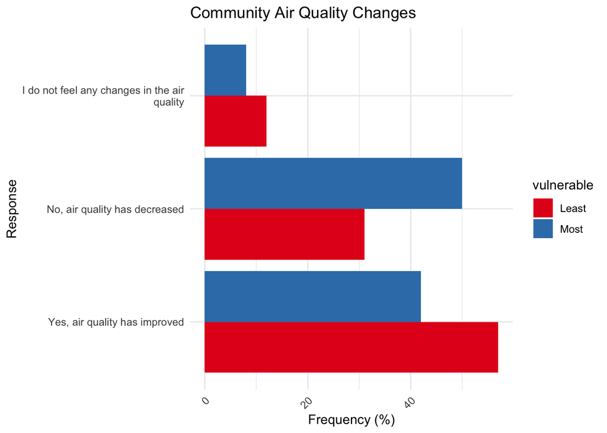

```r
vulnerable_q4_viz
```

```r
datatable(vulnerable_q4_chi)
```

|  | question | statistic | pvalue | degreeof |
| --- | --- | --- | --- | --- |
| 1 | I do not feel any changes in the air quality | 2.667 | 0.102 | 1 |
| 2 | No, air quality has decreased | 2.579 | 0.108 | 1 |
| 3 | Yes, air quality has improved | 12.448 | 0 | 1 |

6. **Did you know Particulate matter (PM) and ground-level Ozone are common air contaminants harmful to human health?** (Multi-choice)
- Yes
- No

```r
datatable(vulnerable_q6)
```

|  | vulnerable | question | n | total | freq |
| --- | --- | --- | --- | --- | --- |
| 1 | Least | No | 9 | 42 | 21 |
| 2 | Least | Yes | 33 | 42 | 79 |
| 3 | Most | No | 2 | 12 | 17 |
| 4 | Most | Yes | 10 | 12 | 83 |

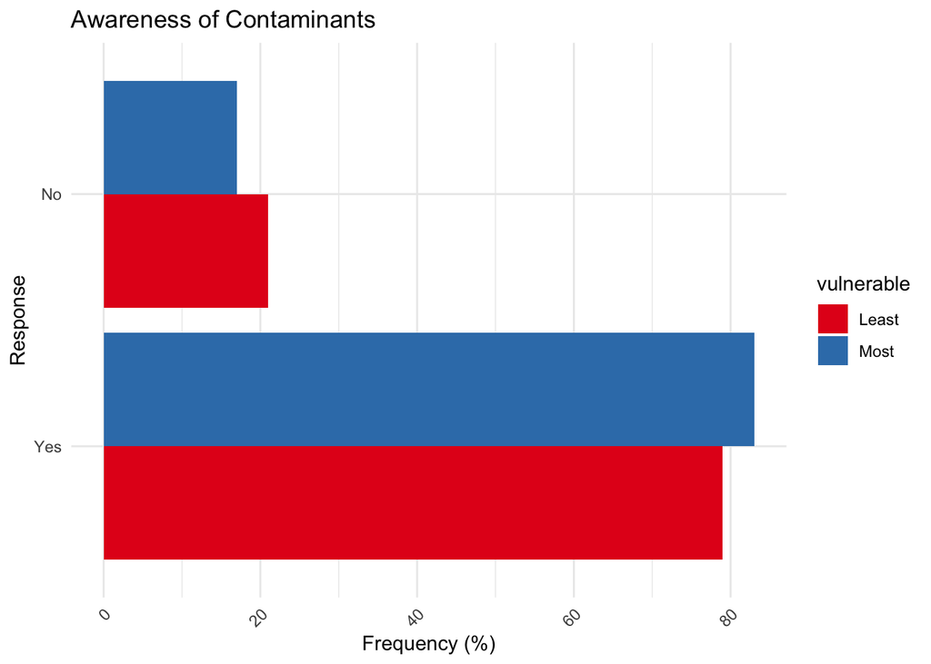

```r
vulnerable_q6_viz
```

```r
datatable(vulnerable_q6_chi)
```

|  | question | statistic | pvalue | degreeof |
| --- | --- | --- | --- | --- |
| 1 | No | 4.455 | 0.035 | 1 |
| 2 | Yes | 12.302 | 0 | 1 |

```r
datatable(vulnerable_q7)
```

|  | vulnerable | question | n | total | freq |
| --- | --- | --- | --- | --- | --- |
| 1 | Least | Other: Áreas de recreación | 1 | 42 | 2 |
| 2 | Least | Residential areas | 20 | 42 | 48 |
| 3 | Least | Schools | 13 | 42 | 31 |
| 4 | Least | Shopping area | 16 | 42 | 38 |
| 5 | Most | Residential areas | 8 | 12 | 67 |
| 6 | Most | Schools | 5 | 12 | 42 |
| 7 | Most | Shopping area | 2 | 12 | 17 |

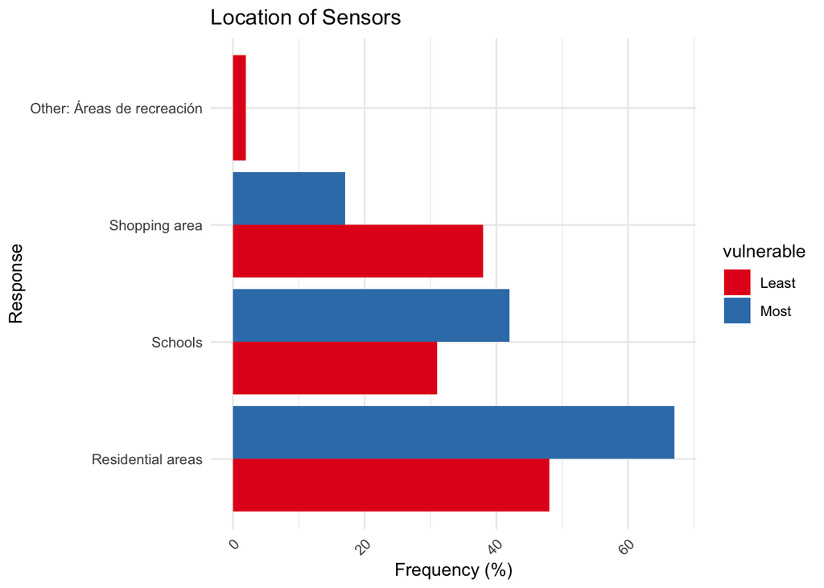

```r
vulnerable_q7_viz
```

```r
datatable(vulnerable_q7_chi)
```

|  | question | statistic | pvalue | degreeof |
| --- | --- | --- | --- | --- |
| 1 | Other: Áreas de recreación | 1 | 0.317 | 1 |
| 2 | Residential areas | 5.143 | 0.023 | 1 |
| 3 | Schools | 3.556 | 0.059 | 1 |
| 4 | Shopping area | 10.889 | 0.001 | 1 |

9. **If air quality becomes an issue and alerts need to be sent, how would you like to receive information about the air quality in your neighborhood?** (Multi-choice)

```r
datatable(vulnerable_q9)
```

|  | vulnerable | question | n | total | freq |
| --- | --- | --- | --- | --- | --- |
| 1 | Least | Newsletter from the city/county to your email | 28 | 42 | 67 |
| 2 | Least | Newsletters from the city/county to your email | 1 | 42 | 2 |
| 3 | Least | Social Media | 25 | 42 | 60 |
| 4 | Least | Text Messages | 28 | 42 | 67 |
| 5 | Least | neighborhood associations | 15 | 42 | 36 |
| 6 | Most | Neighborhood associations | 1 | 12 | 8 |
| 7 | Most | Newsletter from the city/county to your email | 6 | 12 | 50 |
| 8 | Most | Social Media | 4 | 12 | 33 |
| 9 | Most | Text Messages | 10 | 12 | 83 |
| 10 | Most | neighborhood associations | 2 | 12 | 17 |

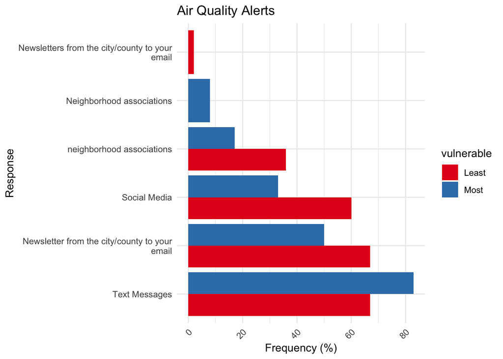

```r
vulnerable_q9_viz
```

```r
datatable(vulnerable_q9_chi)
```

|  | question | statistic | pvalue | degreeof |
| --- | --- | --- | --- | --- |
| 1 | Neighborhood associations | 1 | 0.317 | 1 |
| 2 | Newsletter from the city/county to your email | 14.235 | 0 | 1 |
| 3 | Newsletters from the city/county to your email | 1 | 0.317 | 1 |
| 4 | Social Media | 15.207 | 0 | 1 |
| 5 | Text Messages | 8.526 | 0.004 | 1 |
| 6 | neighborhood associations | 9.941 | 0.002 | 1 |

```r
datatable(vulnerable_q10)
```

|  | vulnerable | question | n | total | freq |
| --- | --- | --- | --- | --- | --- |
| 1 | Least | Attending a community outreach event | 5 | 42 | 12 |
| 2 | Least | Attending the community outreach event | 15 | 42 | 36 |
| 3 | Least | Connect with local working group to be the messenger to deliver this information to your neighborhood | 22 | 42 | 52 |
| 4 | Most | Attending a community outreach event | 1 | 12 | 8 |
| 5 | Most | Attending the community outreach event | 7 | 12 | 57.99999999999999 |
| 6 | Most | Connect with local working group to be the messenger to deliver this information to your neighborhood | 3 | 12 | 25 |
| 7 | Most | Other: Online feedback form | 1 | 12 | 8 |

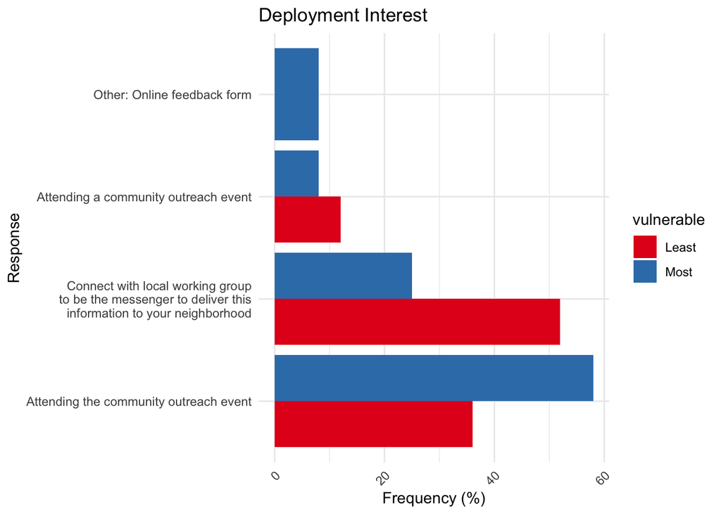

```r
vulnerable_q10_viz
```

```r
#datatable(vulnerable_q10_chi)
```